# Hướng dẫn vẽ heatmap theo khu vực địa lý

Duc Nguyen | Chuyên đào tạo kỹ năng R | `www.tuhocr.com`

Mar 25, 2023

**Tiếp nối từ câu chuyện vẽ heatmap cho bản đồ thế giới theo sản lượng các loại nông sản ở link này**

`https://rpubs.com/tuhocr/huong-dan-ve-world-map`

**Hôm nay mình sẽ hướng dẫn các bạn các extract thông tin world ra region để vẽ về tình hình sản xuất lúa gạo ở khu vực Đông Nam Á nhé.**

### **Import dataset**

- [Rice production](https://docs.google.com/spreadsheets/d/11EU8qJt14EflHgU2cCENQnIJUZKIClAMWHaFa_CEchk/edit?usp=share_link)

**Load dataset vào R**

```r
library("googlesheets4")
options(scipen = 15, digits = 15, width = 200)

rice_production <- read_sheet('11EU8qJt14EflHgU2cCENQnIJUZKIClAMWHaFa_CEchk')
```

### **Clean dataset**

Dataset khi import vào R có một số chỗ nho nhỏ cần làm sạch để gom vào dataset master trước khi dùng để vẽ đồ thị world map. Đơn vị quy chuẩn là *metric ton* (1000 kg).

```r
### Cleaning dataset rice_production
rice_production_df <- as.data.frame(rice_production)
rice_production_2020 <- rice_production_df[, c(2, 3)] # chọn những cột quan tâm

### Loại NA
rice_production_2020 <- na.omit(rice_production_2020)

names(rice_production_2020) <- c("country", "rice_2020")

### In dataset
head(rice_production_2020, n = 10)
```

```
##        country rice_2020
## 2        China 211860000
## 3        India 178305000
## 4   Bangladesh  54905891
## 5    Indonesia  54649202
## 6      Vietnam  42758897
## 7     Thailand  30231025
## 8      Myanmar  25100000
## 9  Philippines  19294856
## 10      Brazil  11091011
## 11    Cambodia  10960000
```

### **Merge dataset**

Sau khi đã có các dataset con, ta sẽ gộp các dataset này căn cứ theo cột `country`.

```r
options("max.print" = 5000)

rice_production_2020 -> data_4

### In dataset master
dim(data_4) # có 113 quốc gia có thông tin sản xuất lúa gạo
```

```
## [1] 113   2
```

```r
data_4
```

```
##                              country rice_2020
## 2                              China 211860000
## 3                              India 178305000
## 4                         Bangladesh  54905891
## 5                          Indonesia  54649202
## 6                            Vietnam  42758897
## 7                           Thailand  30231025
## 8                            Myanmar  25100000
## 9                        Philippines  19294856
## 10                            Brazil  11091011
## 11                          Cambodia  10960000
## 12                     United States  10322990
## 13                             Japan   9706250
## 14                          Pakistan   8419276
## 15                           Nigeria   8172000
```

[output cut: 99 more lines]

### **Chuẩn bị dataset `world`**

Để vẽ đồ thị world map, chúng ta sẽ đưa dataset master này vào data frame `world` vốn là dữ liệu chứa thông tin địa lý các quốc gia trên thế giới.

```r
library(ggplot2)
library(sf)
library(tidyverse)
library(ggrepel)
library(rnaturalearth)
library(rnaturalearthhires)
library(viridis)
library(ggspatial)
library(maps)
library(ggsn)

### Load dataset `world`
world <- ne_countries(scale = "medium", returnclass = "sf")

### Trong dataset `world` có một số quốc gia nhỏ chưa được update thông tin, vì vậy ta tách ra trong data_5
abcd <- c("East Timor", "Eswatini", "Ivory Coast", "Saint Kitts and Nevis", "Saint Vincent and the Grenadines", "Tokelau", "Tuvalu")
sep <- match(abcd, data_4$country)
data_5 <- data_4[-c(109, 31), ]

### Khớp lại tên các quốc gia trong `data_5` và `world`

# grep(pattern = "Antigua", world$name)
world$name[15] <- "Antigua and Barbuda"

# grep(pattern = "Bosnia", world$name)
world$name[27] <- "Bosnia and Herzegovina"

# grep(pattern = "Cook", world$name)
world$name[38] <- "Central African Republic"

# grep(pattern = "Central African", world$name)
world$name[47] <- "Cook Islands"

# grep(pattern = "Czech", world$name)
world$name[57] <- "Czech Republic"

# grep(pattern = "Congo", world$name)
world$name[45] <- "Democratic Republic of the Congo"
world$name[46] <- "Republic of the Congo"

# grep(pattern = "Dominican", world$name)
world$name[62] <- "Dominican Republic"

# grep(pattern = "Guinea", world$name)
world$name[84] <- "Equatorial Guinea"

# grep(pattern = "Micronesia", world$name)
world$name[75] <- "Federated States of Micronesia"

# grep(pattern = "Polynesia", world$name)
world$name[181] <- "French Polynesia"

# grep(pattern = "Lao", world$name)
world$name[122] <- "Laos"

# grep(pattern = "Korea", world$name)
world$name[177] <- "North Korea"
world$name[119] <- "South Korea"

# grep(pattern = "Macedonia", world$name)
world$name[142] <- "North Macedonia"

# grep(pattern = "São", world$name)
world$name[202] <- "São Tomé and Príncipe"

# grep(pattern = "Solomon", world$name)
world$name[194] <- "Solomon Islands"

# grep(pattern = "Sudan", world$name)
world$name[189] <- "South Sudan"

### Kiểm tra toàn bộ tên các quốc gia trong `data_5` đã nằm trong `world` chưa? Kết quả là character(0) là OK.
setdiff(data_5$country, world$name)
```

```
## character(0)
```

**Merge toàn bộ `data_5` vào trong `world` để có thêm các cột liên quan đến sản lượng thực phẩm.**

```r
names(data_5)[1] <- "name"
merge(world, data_5, by = "name", all = TRUE) -> world_production
```

### **Vẽ đồ thị world map**

**Để xem hình độ phân giải cao, các bạn right-click vào hình, chọn Open image in new tab.**

**Sản lượng lúa gạo trên thế giới năm 2020**

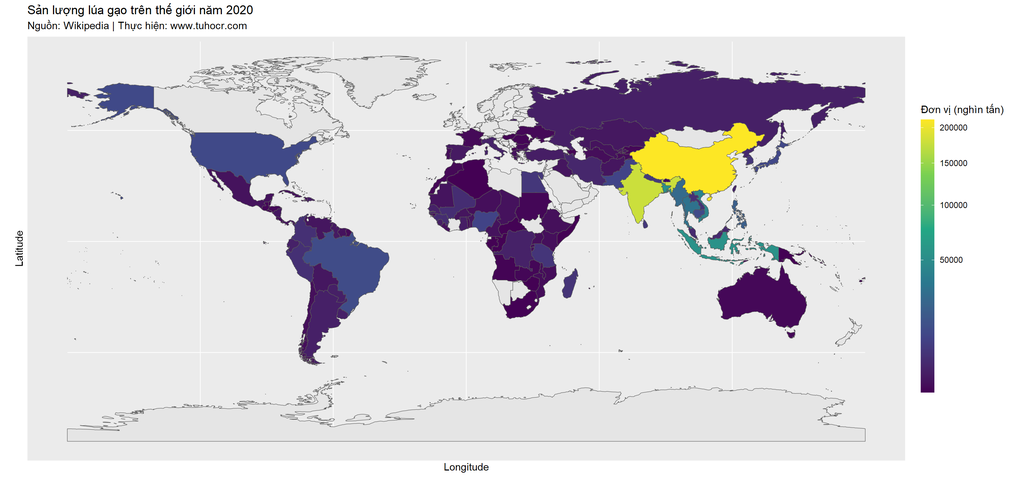

```r
ggplot(data = world_production) +
    geom_sf(aes(fill = rice_2020/1000)) +
    xlab("Longitude") + ylab("Latitude") +
    scale_fill_viridis_c(name = "Đơn vị (nghìn tấn)",
                         option = "D",
                         trans = "sqrt",
                         direction = 1,
                         na.value = "grey90",
                         guide = "colourbar") +
    ggtitle("Sản lượng lúa gạo trên thế giới năm 2020", subtitle = paste0("Nguồn: Wikipedia | Thực hiện: www.tuhocr.com")) +
    theme(legend.position = "right") +
    guides(fill = guide_colourbar(barwidth = 1, barheight = 20))
```

### **Vẽ đồ thị South-East Asia map**

**Danh sách region**

```r
t(t(table(world_production$subregion)))
```

```
##
##                             [,1]
##   Antarctica                   1
##   Australia and New Zealand    4
##   Caribbean                   25
##   Central America              8
##   Central Asia                 5
##   Eastern Africa              19
##   Eastern Asia                 8
##   Eastern Europe              10
##   Melanesia                    5
##   Micronesia                   7
##   Middle Africa                9
##   Northern Africa              7
##   Northern America             5
##   Northern Europe             15
##   Polynesia                    8
##   Seven seas (open ocean)      5
##   South-Eastern Asia          11
##   South America               13
##   Southern Africa              5
##   Southern Asia               10
##   Southern Europe             16
##   Western Africa              17
##   Western Asia                19
##   Western Europe               9
```

**Tách dữ liệu theo region**

```r
south_asia <- subset(world_production, subregion == "South-Eastern Asia")
```

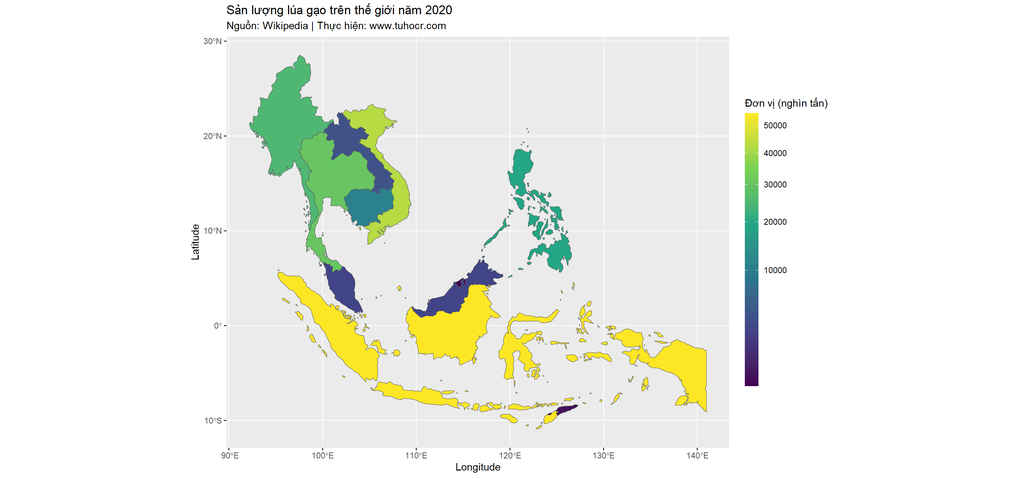

```r
ggplot(data = south_asia) +
    geom_sf(aes(fill = rice_2020/1000)) +
    xlab("Longitude") + ylab("Latitude") +
    scale_fill_viridis_c(name = "Đơn vị (nghìn tấn)",
                         option = "D",
                         trans = "sqrt",
                         direction = 1,
                         na.value = "grey90",
                         guide = "colourbar") +
    ggtitle("Sản lượng lúa gạo trên thế giới năm 2020", subtitle = paste0("Nguồn: Wikipedia | Thực hiện: www.tuhocr.com")) +
    theme(legend.position = "right") +
    guides(fill = guide_colourbar(barwidth = 1, barheight = 20))
```

```r
# ggsave("img.png", height = 18, width = 30, units = 'in', dpi= 200, type = "cairo")
```

### **Làm đồ thị SEA map đẹp hơn**

**Chuẩn bị dữ liệu**

```r
# library(dplyr)
south_asia <- world_production %>% filter(subregion == "South-Eastern Asia") %>%
    select(name, subunit, geometry, rice_2020)

### tên quốc gia

library("sf")
world_points <- st_point_on_surface(world)

world_points <- cbind(world, st_coordinates(st_point_on_surface(world$geometry)))

world_points <- world_points %>% filter(subregion == "South-Eastern Asia")

## chỉnh vị trí tên quốc gia
world_points[9, "Y"] <- 16

world_points[11, "X"] <- 110

world_points[5, "Y"] <- 21

world_points[8, "Y"] <- 2
world_points[8, "X"] <- 107.5

world_points[10, "X"] <- 129
world_points[10, "Y"] <- -9.5

world_points[1, "Y"] <- 6

world_points[2, "X"] <- 109
world_points[2, "Y"] <- -4.5

world_points[7, "Y"] <- 12

# thailand <- subset(world_points, name == "Thailand")
# thailand$Y <- 15
```

**Lấy dữ liệu lúa gạo của các quốc gia Đông Nam Á**

```r
print(south_asia[, c(1, 3)], n = 30)
```

```
## Simple feature collection with 11 features and 2 fields
## Geometry type: MULTIPOLYGON
## Dimension:     XY
## Bounding box:  xmin: 92.17958984375 ymin: -10.90966796875 xmax: 140.976171875 ymax: 28.517041015625
## Geodetic CRS:  +proj=longlat +datum=WGS84 +no_defs +ellps=WGS84 +towgs84=0,0,0
##           name rice_2020                       geometry
## 1       Brunei      2511 MULTIPOLYGON (((115.0267578...
## 2     Cambodia  10960000 MULTIPOLYGON (((103.3177734...
## 3    Indonesia  54649202 MULTIPOLYGON (((122.9489257...
## 4         Laos   3687336 MULTIPOLYGON (((102.1274414...
## 5     Malaysia   2321636 MULTIPOLYGON (((111.3892578...
## 6      Myanmar  25100000 MULTIPOLYGON (((98.18261718...
## 7  Philippines  19294856 MULTIPOLYGON (((120.2503906...
## 8    Singapore        NA MULTIPOLYGON (((103.9697265...
## 9     Thailand  30231025 MULTIPOLYGON (((99.66308593...
## 10 Timor-Leste     69000 MULTIPOLYGON (((124.3193359...
## 11     Vietnam  42758897 MULTIPOLYGON (((106.6174804...
```

```r
rice_full_1 <- readRDS(file = "rice_full_1.rds")

unique(rice_full_1$area)
```

```
##   [1] "Afghanistan"                           "Albania"                               "Algeria"                               "Angola"
##   [5] "Argentina"                             "Australia"                             "Azerbaijan"                            "Bangladesh"
##   [9] "Belize"                                "Benin"                                 "Bhutan"                                "Bolivia (Plurinational State of)"
##  [13] "Brazil"                                "Brunei Darussalam"                     "Bulgaria"                              "Burkina Faso"
##  [17] "Burundi"                               "Cambodia"                              "Cameroon"                              "Central African Republic"
##  [21] "Chad"                                  "Chile"                                 "China, Hong Kong SAR"                  "China, Taiwan Province of"
##  [25] "China, mainland"                       "Colombia"                              "Comoros"                               "Congo"
##  [29] "Costa Rica"                            "Cuba"                                  "Côte d'Ivoire"                         "Democratic People's Republic of Korea"
##  [33] "Democratic Republic of the Congo"      "Dominican Republic"                    "Ecuador"                               "Egypt"
##  [37] "El Salvador"                           "Eswatini"                              "Ethiopia"                              "Fiji"
##  [41] "France"                                "French Guyana"                         "Gabon"                                 "Gambia"
##  [45] "Ghana"                                 "Greece"                                "Guatemala"                             "Guinea"
##  [49] "Guinea-Bissau"                         "Guyana"                                "Haiti"                                 "Honduras"
##  [53] "Hungary"                               "India"                                 "Indonesia"                             "Iran (Islamic Republic of)"
##  [57] "Iraq"                                  "Italy"                                 "Jamaica"                               "Japan"
```

[output cut: 17 more lines]

```r
gsub(pattern = "Brunei Darussalam", replacement = "Brunei", rice_full_1$area, fixed = TRUE) -> rice_full_1$area

gsub(pattern = "Lao People's Democratic Republic", replacement = "Laos", rice_full_1$area, fixed = TRUE) -> rice_full_1$area

gsub(pattern = "Viet Nam", replacement = "Vietnam", rice_full_1$area, fixed = TRUE) -> rice_full_1$area

unique(rice_full_1$area)
```

```
##   [1] "Afghanistan"                           "Albania"                               "Algeria"                               "Angola"
##   [5] "Argentina"                             "Australia"                             "Azerbaijan"                            "Bangladesh"
##   [9] "Belize"                                "Benin"                                 "Bhutan"                                "Bolivia (Plurinational State of)"
##  [13] "Brazil"                                "Brunei"                                "Bulgaria"                              "Burkina Faso"
##  [17] "Burundi"                               "Cambodia"                              "Cameroon"                              "Central African Republic"
##  [21] "Chad"                                  "Chile"                                 "China, Hong Kong SAR"                  "China, Taiwan Province of"
##  [25] "China, mainland"                       "Colombia"                              "Comoros"                               "Congo"
##  [29] "Costa Rica"                            "Cuba"                                  "Côte d'Ivoire"                         "Democratic People's Republic of Korea"
##  [33] "Democratic Republic of the Congo"      "Dominican Republic"                    "Ecuador"                               "Egypt"
##  [37] "El Salvador"                           "Eswatini"                              "Ethiopia"                              "Fiji"
##  [41] "France"                                "French Guyana"                         "Gabon"                                 "Gambia"
##  [45] "Ghana"                                 "Greece"                                "Guatemala"                             "Guinea"
##  [49] "Guinea-Bissau"                         "Guyana"                                "Haiti"                                 "Honduras"
##  [53] "Hungary"                               "India"                                 "Indonesia"                             "Iran (Islamic Republic of)"
##  [57] "Iraq"                                  "Italy"                                 "Jamaica"                               "Japan"
```

[output cut: 17 more lines]

```r
######### rice in SEA

sea_rice_data <- rice_full_1 |> subset(area == "Brunei" |
                                       area == "Cambodia" |
                                       area == "Indonesia" |
                                       area == "Laos" |
                                       area == "Malaysia" |
                                       area == "Myanmar" |
                                       area == "Philippines" |
                                       area == "Thailand" |
                                       area == "Timor-Leste" |
                                       area == "Vietnam"
                                       )

#####

sea_rice_data_2000 <- sea_rice_data |> subset(year == 2000)

singapore_2000 <- data.frame(area = "Singapore", item = "Rice", year = 2000,
                        value.production = NA,
                        value.area_harvested = NA)

sea_rice_data_2000 <- rbind(sea_rice_data_2000, singapore_2000)

sea_rice_data_2000 <- sea_rice_data_2000 |> dplyr::arrange(area)

row.names(sea_rice_data_2000) <- NULL

south_asia$rice_2000 <- sea_rice_data_2000$value.production

###############

sea_rice_data_2021 <- sea_rice_data |> subset(year == 2021)

singapore_2021 <- data.frame(area = "Singapore", item = "Rice", year = 2021,
                        value.production = NA,
                        value.area_harvested = NA)

sea_rice_data_2021 <- rbind(sea_rice_data_2021, singapore_2021)

sea_rice_data_2021 <- sea_rice_data_2021 |> dplyr::arrange(area)

row.names(sea_rice_data_2021) <- NULL

south_asia$rice_2021 <- sea_rice_data_2021$value.production
```

```r
# extracting the capitals of SE Asia
capital <- maps::world.cities %>%
    filter(country.etc %in% south_asia$subunit, capital == 1)


# convert capital to sf object
capital <- st_as_sf(capital, coords = c("long", "lat"), crs = 4326)
```

[figure not shown]

```r
ggplot(data = world_production) +
    geom_sf() +
    geom_sf(data = south_asia, aes(fill = rice_2000/1000)) +
    xlab("Longitude") + ylab("Latitude") +
    scale_fill_distiller(palette = "YlGn", direction = 1,
                         name = "Đơn vị (nghìn tấn)",
                         na.value = "grey90",
                         guide = "colourbar") +
    # scale_fill_viridis_c(name = "Đơn vị (nghìn tấn)",
    #                      option = "plasma",
    #                      trans = "sqrt",
    #                      direction = 1,
    #                      na.value = "grey90",
    #                      guide = "colourbar") +
    ggtitle("Sản lượng lúa gạo khu vực Đông Nam Á vào năm 2000", subtitle = paste0("Nguồn: FAOSTAT | Thực hiện: Duc Nguyen | tuhocr.com")) +
    theme(legend.position = "right") +
    theme(plot.title = element_text(face = "bold", colour = "darkgreen"),
          plot.subtitle = element_text(face = "bold", colour = "blue")) +
    guides(fill = guide_colourbar(barwidth = 1, barheight = 20)) +

    # adding capital cities as points
    geom_sf(data = capital, size = 1, color = "red") +

    geom_text(data = world_points, aes(x = X, y = Y, label = name),
              color = "darkblue", fontface = "bold", check_overlap = FALSE) +

    # setting the limits for South East Asia region
    coord_sf(xlim = c(88.594382881345, 152.93774260658),
             ylim = c(31.29186472309,-12.375471986864), expand = FALSE) +

    # adding scale and compass
    annotation_scale(location = "tr", pad_x = unit(0.5, "cm"), pad_y = unit(0.5, "cm")) +
  #   scalebar(data = south_asia, location = "topleft", dist = 500,
  # dist_unit = "km", transform = TRUE,  model = "International") +
    # annotation_north_arrow(location = "tr", which_north = "true",
    #                        pad_x = unit(0.3, "in"), pad_y = unit(0.5, "in"),
    #                        style = north_arrow_fancy_orienteering) +
    ggspatial::annotation_north_arrow(
    location = "tr", which_north = "true",
    pad_x = unit(0.4, "in"), pad_y = unit(0.4, "in"),
    style = ggspatial::north_arrow_nautical(
      fill = c("grey40", "white"),
      line_col = "grey20",
      text_family = "ArcherPro Book"
    )) +
    annotate(geom = "text", x = 113.5, y = 12, label = "South East \nAsian Sea",
        fontface = "italic", color = "grey22", size = 4) +

    # adding color the waters and other aesthetics
    theme(panel.background = element_rect(fill = "aliceblue"))

library(png) ## dùng đề chèn file ảnh
library(grid) ## canh chỉnh vị trí ảnh
logor <- readPNG("logo-blue.png")
grid.raster(logor, x = 0.91, y = 0.89, width = 0.1)
```

[figure not shown]

```r
ggplot(data = world_production) +
    geom_sf() +
    geom_sf(data = south_asia, aes(fill = rice_2021/1000)) +
    xlab("Longitude") + ylab("Latitude") +
    scale_fill_distiller(palette = "YlGn", direction = 1,
                         name = "Đơn vị (nghìn tấn)",
                         na.value = "grey90",
                         guide = "colourbar") +
    # scale_fill_viridis_c(name = "Đơn vị (nghìn tấn)",
    #                      option = "plasma",
    #                      trans = "sqrt",
    #                      direction = 1,
    #                      na.value = "grey90",
    #                      guide = "colourbar") +
    ggtitle("Sản lượng lúa gạo khu vực Đông Nam Á vào năm 2021", subtitle = paste0("Nguồn: FAOSTAT | Thực hiện: Duc Nguyen | tuhocr.com")) +
    theme(legend.position = "right") +
    theme(plot.title = element_text(face = "bold", colour = "red"),
          plot.subtitle = element_text(face = "bold", colour = "blue")) +
    guides(fill = guide_colourbar(barwidth = 1, barheight = 20)) +

    # adding capital cities as points
    geom_sf(data = capital, size = 1, color = "red") +

    geom_text(data = world_points, aes(x = X, y = Y, label = name),
              color = "darkblue", fontface = "bold", check_overlap = FALSE) +

    # setting the limits for South East Asia region
    coord_sf(xlim = c(88.594382881345, 152.93774260658),
             ylim = c(31.29186472309,-12.375471986864), expand = FALSE) +

    # adding scale and compass
    annotation_scale(location = "tr", pad_x = unit(0.5, "cm"), pad_y = unit(0.5, "cm")) +
  #   scalebar(data = south_asia, location = "topleft", dist = 500,
  # dist_unit = "km", transform = TRUE,  model = "International") +
    # annotation_north_arrow(location = "tr", which_north = "true",
    #                        pad_x = unit(0.3, "in"), pad_y = unit(0.5, "in"),
    #                        style = north_arrow_fancy_orienteering) +
    ggspatial::annotation_north_arrow(
    location = "tr", which_north = "true",
    pad_x = unit(0.4, "in"), pad_y = unit(0.4, "in"),
    style = ggspatial::north_arrow_nautical(
      fill = c("grey40", "white"),
      line_col = "grey20",
      text_family = "ArcherPro Book"
    )) +
    annotate(geom = "text", x = 113.5, y = 12, label = "South East \nAsian Sea",
        fontface = "italic", color = "grey22", size = 4) +

    # adding color the waters and other aesthetics
    theme(panel.background = element_rect(fill = "aliceblue"))

library(png) ## dùng đề chèn file ảnh
library(grid) ## canh chỉnh vị trí ảnh
logor <- readPNG("logo-blue.png")
grid.raster(logor, x = 0.91, y = 0.89, width = 0.1)
```

Các bạn cũng có thể đối chiếu kết quả này với các đồ thị world map từ

- `https://www.visualcapitalist.com/cp/mapped-food-production-around-the-world/`
- `https://www.fao.org/faostat/en/#data`

### Tài liệu tham khảo

1. `http://aejaffe.com/summerR_2015/modules/mapping_module.html`
2. `https://blog.rwhitedwarf.com/post/map_any_region_with_ggplot2_part_ii/`
3. `https://medium.com/geekculture/how-to-map-data-with-r-8333110dff5b`
4. `https://r-spatial.org/r/2018/10/25/ggplot2-sf.html`

### Sơ kết

Trên đây là hướng dẫn vẽ heatmap theo khu vực địa lý. Để học R bài bản từ A đến Z, thân mời Bạn tham gia **khóa học “HDSD R để xử lý dữ liệu”** **để có nền tảng vững chắc về R nhằm tự tay làm các câu chuyện dữ liệu của riêng mình!**

**ĐĂNG KÝ NGAY: `https://www.tuhocr.com/register`**

**Hướng dẫn cài đặt package `tuhocr` `https://tuhocr.github.io/`**